# Homework 11

Solutions will be available after Monday, November 9, 2026.

## Question 1: Implementing K-means

K-means is a relatively simple algorithm that we can write ourselves. For Questions 1 and 2, do not use an existing function that performs K-means directly.

Generate 10 observations with two independent standard normal coordinates. Set a random seed and report it. Randomly assign the observations to $K=2$ clusters, making sure neither cluster is empty. Let $C(i)$ denote the cluster assigned to observation $x_i$, and let $m_k$ denote the mean of cluster $k$.

1. Perform one iteration: calculate the cluster means, then assign each observation to its closest mean using Euclidean distance. Report the means and updated assignments, and plot the observations colored by their updated assignments.

### Solution

```
Random seed: 432

Initial Cluster Means:
            Mean X1   Mean X2
Cluster 1  0.027476 -0.138621
Cluster 2  0.763741 -0.259952

Cluster Assignments:
 Observation        X1        X2  Initial Cluster  Updated Cluster
           1  0.186877  0.034497                1                1
           2 -0.384754  0.464590                1                1
           3  0.600893 -1.735851                1                2
           4 -0.312009  0.307777                1                1
           5 -0.226074 -0.073054                1                1
           6  0.001010  0.332676                1                1
           7  1.950864 -0.794727                2                2
           8  0.651799 -0.042164                2                2
           9 -0.311440  0.057034                2                1
          10  0.326389 -0.300983                1                1
```

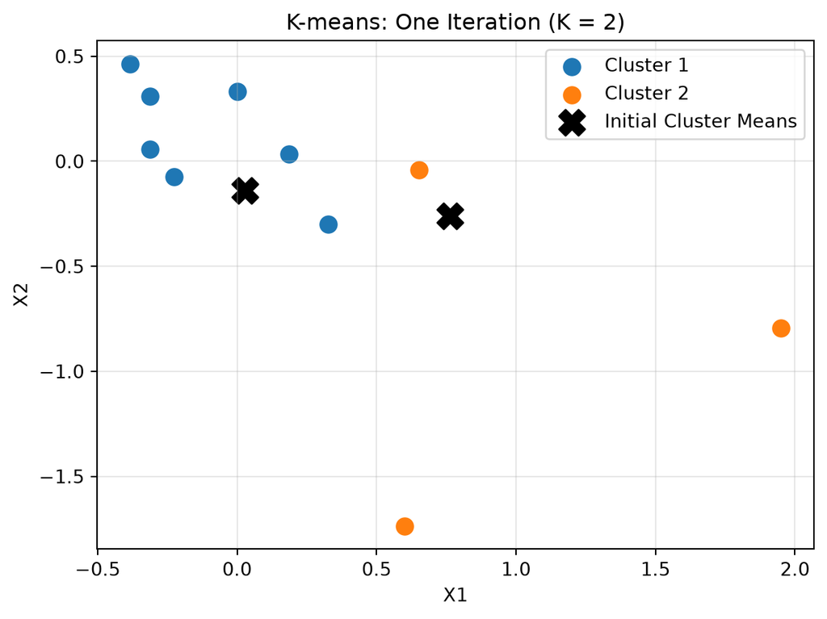

```python
import numpy as np
import pandas as pd
import matplotlib.pyplot as plt

# Set random seed
np.random.seed(432)

# Generate 10 observations with two independent N(0,1) coordinates
X = np.random.randn(10, 2)

# Randomly assign observations to K = 2 clusters
# Ensure neither cluster is empty
initial_clusters = np.random.choice([0, 1], size=10)

while len(np.unique(initial_clusters)) < 2:
    initial_clusters = np.random.choice([0, 1], size=10)

# Step 1: Calculate initial cluster means
means = np.array([
    X[initial_clusters == k].mean(axis=0)
    for k in range(2)
])

# Step 2: Calculate Euclidean distances to each mean
distances = np.sqrt(
    np.sum((X[:, np.newaxis, :] - means[np.newaxis, :, :])**2, axis=2)
)

# Step 3: Assign each observation to the closest mean
updated_clusters = np.argmin(distances, axis=1)

# Display cluster means
means_df = pd.DataFrame(
    means,
    columns=["Mean X1", "Mean X2"],
    index=["Cluster 1", "Cluster 2"]
)

print("Random seed: 432")
print("\nInitial Cluster Means:")
print(means_df)

# Display updated assignments
results = pd.DataFrame({
    "Observation": np.arange(1, 11),
    "X1": X[:, 0],
    "X2": X[:, 1],
    "Initial Cluster": initial_clusters + 1,
    "Updated Cluster": updated_clusters + 1
})

print("\nCluster Assignments:")
print(results.to_string(index=False))

# Plot observations colored by updated assignments
plt.figure(figsize=(7, 5))

for k in range(2):
    plt.scatter(
        X[updated_clusters == k, 0],
        X[updated_clusters == k, 1],
        label=f"Cluster {k+1}",
        s=80
    )

# Plot the cluster means used for reassignment
plt.scatter(
    means[:, 0],
    means[:, 1],
    c="black",
    marker="X",
    s=200,
    label="Initial Cluster Means"
)

plt.xlabel("X1")
plt.ylabel("X2")
plt.title("K-means: One Iteration (K = 2)")
plt.legend()
plt.grid(alpha=0.3)
plt.show()
```

Using random seed 432, we generated 10 observations with two independent standard normal coordinates and randomly assigned them to two nonempty clusters.

The initial cluster means were

$$m_1 = (0.0275, -0.1386), \qquad
m_2 = (0.7637, -0.2600).$$

After reassigning each observation to its nearest cluster mean using Euclidean distance, Observation 3 moved from Cluster 1 to Cluster 2, and Observation 9 moved from Cluster 2 to Cluster 1. The remaining observations retained their initial assignments.

The plot shows the updated cluster assignments, with black crosses representing the initial cluster means used for reassignment.

2. Write a function that repeats these two steps until the assignments stop changing or a specified maximum number of iterations is reached. Your function should work for a data matrix with any number of variables and a chosen number of clusters $K$. Start from a nonempty assignment to each cluster; if a cluster becomes empty during iteration, keep its previous mean. Recalculate the cluster means from the final assignments before returning them. Return the final assignments, cluster means, and within-cluster sum of squares,

   $$\sum_{k=1}^K\sum_{i:\,C(i)=k}\lVert x_i-m_k\rVert^2.$$

### Solution

```python
def my_kmeans(X, K, initial_clusters, max_iter=100):
    X = np.asarray(X, dtype=float)
    n, p = X.shape

    # Check inputs
    if K < 1 or K > n:
        raise ValueError("K must be between 1 and n.")

    clusters = np.asarray(initial_clusters, dtype=int).copy()

    if len(clusters) != n:
        raise ValueError("Initial assignments must have length n.")

    if not np.array_equal(np.unique(clusters), np.arange(K)):
        raise ValueError("Each cluster must initially be nonempty.")

    if max_iter < 1:
        raise ValueError("max_iter must be at least 1.")

    # Calculate initial cluster means
    means = np.array([
        X[clusters == k].mean(axis=0)
        for k in range(K)
    ])

    # Repeat until convergence or max_iter
    for iteration in range(max_iter):

        # Step 1: Calculate cluster means
        for k in range(K):
            if np.any(clusters == k):
                means[k] = X[clusters == k].mean(axis=0)
            # If empty, keep the previous mean

        # Step 2: Calculate squared Euclidean distances
        distances = np.sum(
            (X[:, None, :] - means[None, :, :])**2,
            axis=2
        )

        # Assign observations to the closest cluster
        new_clusters = np.argmin(distances, axis=1)

        # Stop if assignments do not change
        if np.array_equal(new_clusters, clusters):
            break

        clusters = new_clusters

    # Recalculate means from FINAL assignments
    for k in range(K):
        if np.any(clusters == k):
            means[k] = X[clusters == k].mean(axis=0)

    # Calculate within-cluster sum of squares
    wcss = np.sum(
        (X - means[clusters])**2
    )

    return {
        "clusters": clusters,
        "means": means,
        "wcss": wcss,
        "iterations": iteration + 1
    }


# Apply the function to the same data from Question 1(a)
result = my_kmeans(
    X,
    K=2,
    initial_clusters=initial_clusters,
    max_iter=100
)

print("Final Cluster Assignments:")
print(result["clusters"] + 1)

print("\nFinal Cluster Means:")
print(result["means"])

print("\nWithin-Cluster Sum of Squares (WCSS):")
print(result["wcss"])

print("\nNumber of Iterations:")
print(result["iterations"])
```

```
Final Cluster Assignments:
[1 1 2 1 1 1 2 1 1 1]

Final Cluster Means:
[[-0.00852527  0.09754666]
 [ 1.27587805 -1.2652892 ]]

Within-Cluster Sum of Squares (WCSS):
2.7605420189927927

Number of Iterations:
3
```

Using the same data and initial assignments from Question 1(a), we implemented K-means with $K=2$ and a maximum of 100 iterations.

The algorithm converged after 3 iterations, producing the following final cluster means:

$$m_1 = (-0.0085, 0.0975), \qquad
m_2 = (1.2759, -1.2653).$$

The final cluster assignments were

$$C = (1,1,2,1,1,1,2,1,1,1).$$

The final within-cluster sum of squares was

$$\mathrm{WCSS} = 2.7605.$$

This indicates the total squared distance between observations and their assigned cluster means. The algorithm stopped because the cluster assignments no longer changed.

3. Apply your function to the same 10 observations from two different random initial assignments. Report the final plots, cluster means, and within-cluster sums of squares. Do the two runs produce the same grouping and objective value? Explain your findings.

### Solution

```
Run 1
Initial Assignments: [1 1 1 2 2 1 2 2 2 2]
Final Assignments: [1 1 2 1 1 1 2 2 1 2]
Final Cluster Means:
[[-0.17439833  0.18725337]
 [ 0.88248598 -0.71843133]]
WCSS: 3.722317383837811
Iterations: 3

Run 2
Initial Assignments: [2 1 1 1 2 2 2 1 1 2]
Final Assignments: [1 1 2 1 1 1 2 2 1 2]
Final Cluster Means:
[[-0.17439833  0.18725337]
 [ 0.88248598 -0.71843133]]
WCSS: 3.722317383837811
Iterations: 2

Comparison:
Same grouping (ignoring cluster labels): True
Same WCSS: True
```

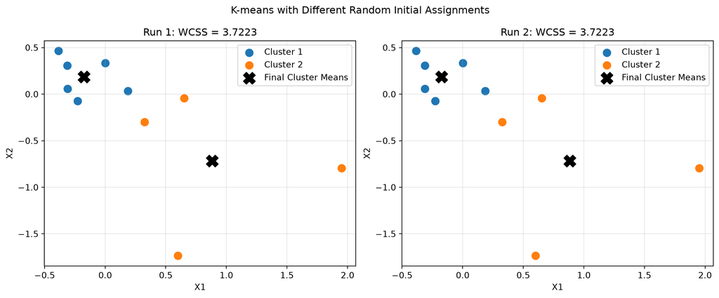

```
  Run    Cluster 1 Mean    Cluster 2 Mean     WCSS  Iterations
Run 1 [-0.1744, 0.1873] [0.8825, -0.7184] 3.722317           3
Run 2 [-0.1744, 0.1873] [0.8825, -0.7184] 3.722317           2
```

```python
# Use the same X from Question 1(a)
K = 2
rng = np.random.default_rng(433)

# Generate nonempty random assignments
def random_initial_assignments(n, K, rng):
    while True:
        clusters = rng.integers(0, K, size=n)
        if len(np.unique(clusters)) == K:
            return clusters

# Generate two different initial assignments
init1 = random_initial_assignments(len(X), K, rng)

init2 = random_initial_assignments(len(X), K, rng)
while np.array_equal(init1, init2):
    init2 = random_initial_assignments(len(X), K, rng)

# Run K-means using the function from Question 1(b)
result1 = my_kmeans(X, K=2, initial_clusters=init1)
result2 = my_kmeans(X, K=2, initial_clusters=init2)

# Display results
for i, (init, result) in enumerate(
    [(init1, result1), (init2, result2)], start=1
):
    print(f"\nRun {i}")
    print("Initial Assignments:", init + 1)
    print("Final Assignments:", result["clusters"] + 1)
    print("Final Cluster Means:")
    print(result["means"])
    print("WCSS:", result["wcss"])
    print("Iterations:", result["iterations"])

# Compare results
# Account for possible swapping of cluster labels
same_grouping = (
    np.array_equal(result1["clusters"], result2["clusters"])
    or np.array_equal(result1["clusters"], 1 - result2["clusters"])
)

same_wcss = np.isclose(
    result1["wcss"],
    result2["wcss"]
)

print("\nComparison:")
print("Same grouping (ignoring cluster labels):", same_grouping)
print("Same WCSS:", same_wcss)

fig, axes = plt.subplots(1, 2, figsize=(12, 5))

for ax, result, title in zip(
    axes,
    [result1, result2],
    ["Run 1", "Run 2"]
):

    clusters = result["clusters"]
    means = result["means"]

    # Plot observations by final cluster assignments
    for k in range(K):
        ax.scatter(
            X[clusters == k, 0],
            X[clusters == k, 1],
            s=80,
            label=f"Cluster {k+1}"
        )

    # Plot final cluster means
    ax.scatter(
        means[:, 0],
        means[:, 1],
        c="black",
        marker="X",
        s=200,
        label="Final Cluster Means"
    )

    ax.set_title(
        f"{title}: WCSS = {result['wcss']:.4f}"
    )
    ax.set_xlabel("X1")
    ax.set_ylabel("X2")
    ax.legend()
    ax.grid(alpha=0.3)

plt.suptitle("K-means with Different Random Initial Assignments")
plt.tight_layout()
plt.show()

comparison = pd.DataFrame({
    "Run": ["Run 1", "Run 2"],
    "Cluster 1 Mean": [
        np.round(result1["means"][0], 4),
        np.round(result2["means"][0], 4)
    ],
    "Cluster 2 Mean": [
        np.round(result1["means"][1], 4),
        np.round(result2["means"][1], 4)
    ],
    "WCSS": [
        result1["wcss"],
        result2["wcss"]
    ],
    "Iterations": [
        result1["iterations"],
        result2["iterations"]
    ]
})

print(comparison.to_string(index=False))
```

Both runs converged to the same clustering solution, with identical cluster means and $\mathrm{WCSS}=3.7223$. Run 1 required 3 iterations, while Run 2 required 2.

However, Question 1(b) achieved a lower WCSS of $2.7605$, demonstrating that different initializations can lead to different local solutions.

## Question 2: Image color compression

Pick your favorite color image and use your K-means function from Question 1 to cluster its pixels. For computational efficiency, resize the image to no more than $200\times200$ pixels and use its three RGB color channels.

1. Plot the original image and report its dimensions. Transform it into a data matrix with one observation per pixel and three variables: red, green, and blue. Report the dimensions of this matrix.

### Solution

```
Image dimensions:
Height: 200
Width: 150
Channels: 3
```

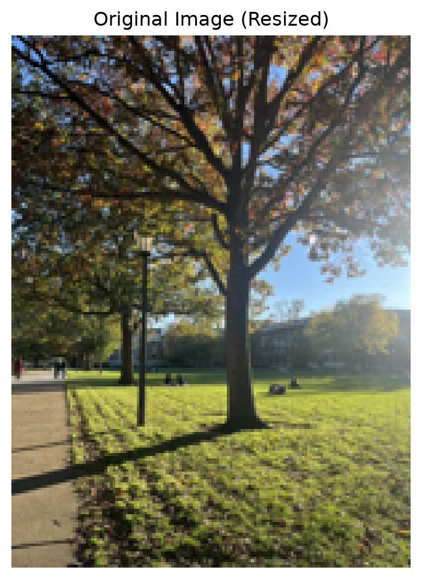

```
RGB Data Matrix Dimensions:
(30000, 3)
```

```python
import numpy as np
import matplotlib.pyplot as plt
from PIL import Image

# Load a color image
image_path = "uiuc_autumn_campus.jpg"
img = Image.open(image_path).convert("RGB")
img.thumbnail((200, 200))

# Resize image to no more than 200 x 200 pixels
img.thumbnail((200, 200))

# Convert to NumPy array
img_array = np.array(img)

# Report image dimensions
height, width, channels = img_array.shape

print("Image dimensions:")
print(f"Height: {height}")
print(f"Width: {width}")
print(f"Channels: {channels}")

# Plot the resized original image
plt.figure(figsize=(6, 6))
plt.imshow(img_array)
plt.title("Original Image (Resized)")
plt.axis("off")
plt.show()

# Transform image into a data matrix
# Each row = one pixel; columns = R, G, B
X_pixels = img_array.reshape(-1, 3)

# Report matrix dimensions
print("\nRGB Data Matrix Dimensions:")
print(X_pixels.shape)
```

We selected a photograph taken on the UIUC campus and resized it to $200 \times 150$ pixels (height $\times$ width), with three RGB color channels.

The image was then reshaped into a data matrix with one observation per pixel and three variables representing red, green, and blue intensities.

The resulting matrix has dimensions

$$(200 \times 150) \times 3 = 30{,}000 \times 3.$$

Thus, the data matrix contains 30,000 observations and 3 variables, ready for K-means clustering.

2. For $K=2,3,5,10$, apply your function to the pixel data. Report the cluster means and within-cluster sum of squares for each $K$. Reconstruct and plot each compressed image by replacing every pixel with its assigned cluster mean. Use the same RGB scale for all fits.

### Solution

```
CLUSTER MEANS (RGB VALUES)
=============================================

K = 2
              Red   Green    Blue
Cluster 1   62.92   60.66   45.62
Cluster 2  148.42  149.47  116.13

K = 3
              Red   Green    Blue
Cluster 1  117.15  113.39   80.88
Cluster 2   51.35   49.63   37.77
Cluster 3  167.32  173.31  144.49

K = 5
              Red   Green    Blue
Cluster 1   77.72   75.17   57.55
Cluster 2   39.13   37.60   27.95
Cluster 3  119.37  116.36   87.76
Cluster 4  167.00  194.19  217.40
Cluster 5  165.03  160.19  102.41

K = 10
               Red   Green    Blue
Cluster 1    32.71   31.21   22.81
Cluster 2   157.44  163.35  165.19
Cluster 3    89.34   90.65   87.29
Cluster 4   181.37  183.53   83.95
Cluster 5   172.66  208.30  238.14
Cluster 6    88.71   82.53   52.65
Cluster 7    58.08   56.85   45.26
Cluster 8   121.33  124.14  122.74
Cluster 9   159.09  147.27   95.07
Cluster 10  125.98  119.60   67.66

WCSS COMPARISON
=============================================
 K          WCSS  Iterations
 2 88,808,484.71          10
 3 58,308,645.15          46
 5 28,401,023.88          65
10 13,450,595.44          67
```

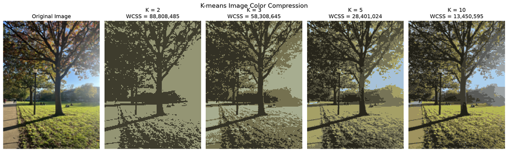

```python
# Question 2(b): Image Color Compression Using K-means

import numpy as np
import pandas as pd
import matplotlib.pyplot as plt

# --------------------------------------------------
# 1. Set up pixel data and K values
# --------------------------------------------------

K_values = [2, 3, 5, 10]

# Convert RGB values to float for K-means calculations
X_rgb = X_pixels.astype(float)

# Set random seed for reproducibility
rng = np.random.default_rng(432)

# Store results
compression_results = {}


# --------------------------------------------------
# 2. Apply K-means for each K
# --------------------------------------------------

for K in K_values:

    # Random initial assignments (all clusters nonempty)
    initial_clusters = random_initial_assignments(
        len(X_rgb), K, rng
    )

    # Apply the K-means function from Question 1(b)
    result = my_kmeans(
        X_rgb,
        K=K,
        initial_clusters=initial_clusters,
        max_iter=100
    )

    # Replace each pixel with its assigned cluster mean
    compressed_pixels = result["means"][result["clusters"]]

    # Reconstruct the compressed image
    compressed_image = compressed_pixels.reshape(
        height, width, 3
    )

    # Keep RGB values on the same [0, 255] scale
    compressed_image = np.clip(
        compressed_image, 0, 255
    ).astype(np.uint8)

    # Store results
    compression_results[K] = {
        "result": result,
        "image": compressed_image
    }


# --------------------------------------------------
# 3. Report cluster means for each K
# --------------------------------------------------

print("CLUSTER MEANS (RGB VALUES)")
print("=" * 45)

for K in K_values:

    means = compression_results[K]["result"]["means"]

    means_df = pd.DataFrame(
        means,
        columns=["Red", "Green", "Blue"],
        index=[f"Cluster {i+1}" for i in range(K)]
    )

    print(f"\nK = {K}")
    print(means_df.round(2).to_string())


# --------------------------------------------------
# 4. Report WCSS and iterations
# --------------------------------------------------

wcss_table = pd.DataFrame({
    "K": K_values,
    "WCSS": [
        compression_results[K]["result"]["wcss"]
        for K in K_values
    ],
    "Iterations": [
        compression_results[K]["result"]["iterations"]
        for K in K_values
    ]
})

print("\nWCSS COMPARISON")
print("=" * 45)

print(
    wcss_table.to_string(
        index=False,
        formatters={
            "WCSS": "{:,.2f}".format
        }
    )
)


# --------------------------------------------------
# 5. Plot original and compressed images
# --------------------------------------------------

fig, axes = plt.subplots(1, 5, figsize=(16, 5))

# Original image
axes[0].imshow(img_array)
axes[0].set_title("Original Image")
axes[0].axis("off")

# Compressed images
for i, K in enumerate(K_values, start=1):

    compressed_image = compression_results[K]["image"]
    wcss = compression_results[K]["result"]["wcss"]

    axes[i].imshow(compressed_image)

    axes[i].set_title(
        f"K = {K}\nWCSS = {wcss:,.0f}"
    )

    axes[i].axis("off")

plt.suptitle(
    "K-means Image Color Compression",
    fontsize=14
)

plt.tight_layout()
plt.show()
```

As $K$ increases from 2 to 10, WCSS decreases and the reconstructed images preserve more color details.

With $K=2$, substantial color information is lost, whereas $K=10$ provides the closest visual approximation to the original image.

This illustrates the trade-off between color compression and reconstruction accuracy.

3. Which value of $K$ would you choose for this image? Briefly justify your choice using the reconstructed images and the within-cluster sums of squares.

### Solution

I would choose $K=10$ because it provides the best balance between image quality and color compression among the four values considered.

The reconstructed image with $K=10$ preserves more color details, particularly in the sky, grass, and trees, making it the closest approximation to the original image.

It also achieves the lowest WCSS of $13{,}450{,}595$, compared with $28{,}401{,}024$ for $K=5$.

Although $K=10$ uses more representative colors than the other options, it still substantially reduces the number of distinct colors while maintaining better visual quality.

## Question 3: Hierarchical clustering of cars

The file `data/mtcars.csv` contains 11 numerical variables for 32 cars, including fuel economy, horsepower, and weight. The `car` column gives the model names; use it to label observations, not as a clustering variable. You may use existing hierarchical clustering functions for this question.

1. Standardize each numerical variable to have mean 0 and standard deviation 1. Using Euclidean distance, perform hierarchical clustering with single, complete, and average linkage. Plot the three dendrograms with the car names and compare the results.

### Solution

```
Data dimensions: (32, 11)
Standardization check: True
```

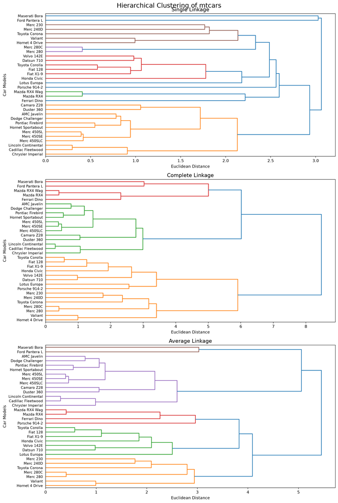

```python
import numpy as np
import pandas as pd
import matplotlib.pyplot as plt

from scipy.cluster.hierarchy import linkage, dendrogram
from scipy.spatial.distance import pdist

# Load the dataset
mtcars = pd.read_csv("data/mtcars.csv")

# Use car names as labels, not clustering variables
car_names = mtcars["car"]

# Select numerical variables
X = mtcars.drop(columns=["car"]).select_dtypes(include="number")

# Standardize each variable (mean = 0, SD = 1)
X_scaled = (X - X.mean()) / X.std(ddof=1)

# Check standardized data
print("Data dimensions:", X_scaled.shape)

print(
    "Standardization check:",
    np.allclose(X_scaled.mean(), 0) and
    np.allclose(X_scaled.std(ddof=1), 1)
)

# Calculate Euclidean distance matrix
distances = pdist(X_scaled, metric="euclidean")

# Perform hierarchical clustering
hc_single = linkage(distances, method="single")
hc_complete = linkage(distances, method="complete")
hc_average = linkage(distances, method="average")

# Plot three dendrograms

fig, axes = plt.subplots(3, 1, figsize=(12, 18))

methods = [
    ("Single Linkage", hc_single),
    ("Complete Linkage", hc_complete),
    ("Average Linkage", hc_average)
]

for ax, (title, Z) in zip(axes, methods):

    dendrogram(
        Z,
        labels=car_names.to_numpy(),
        orientation="right",
        leaf_font_size=9,
        ax=ax
    )

    ax.set_title(title, fontsize=13)
    ax.set_xlabel("Euclidean Distance")
    ax.set_ylabel("Car Models")

plt.suptitle(
    "Hierarchical Clustering of mtcars",
    fontsize=16
)

plt.tight_layout()
plt.show()
```

Single linkage exhibits a chaining effect, resulting in less clearly separated clusters. Complete linkage produces more compact groups, with the final merge occurring at approximately 8.5.

Average linkage provides an intermediate structure. Similar models, such as Mazda RX4 and Mazda RX4 Wag, are grouped closely together across methods.

2. Choose one linkage method and a number of clusters that you consider reasonable. Report the cluster memberships and a table of cluster means on the original variable scales. Describe the main characteristics of the groups and explain your choice using the dendrogram and table. Briefly explain why standardizing the variables matters for this analysis.

### Solution

```
Cluster Sizes:
Cluster
1    15
2    12
3     5
Name: count, dtype: int64

Cluster Memberships:

Cluster 1 (15 cars):
  Datsun 710
  Hornet 4 Drive
  Valiant
  Merc 240D
  Merc 230
  Merc 280
  Merc 280C
  Fiat 128
  Honda Civic
  Toyota Corolla
  Toyota Corona
  Fiat X1-9
  Porsche 914-2
  Lotus Europa
  Volvo 142E

Cluster 2 (12 cars):
  Hornet Sportabout
  Duster 360
  Merc 450SE
  Merc 450SL
  Merc 450SLC
  Cadillac Fleetwood
  Lincoln Continental
  Chrysler Imperial
  Dodge Challenger
  AMC Javelin
  Camaro Z28
  Pontiac Firebird

Cluster 3 (5 cars):
  Mazda RX4
  Mazda RX4 Wag
  Ford Pantera L
  Ferrari Dino
  Maserati Bora

Cluster Means (Original Variable Scales):
           mpg   cyl    disp      hp  drat    wt   qsec    vs    am  gear  carb
Cluster
1        24.65  4.53  131.65   91.33  3.90  2.58  19.16  0.93  0.53  3.93  1.80
2        15.05  8.00  357.62  194.17  3.12  4.10  17.14  0.00  0.00  3.00  3.08
3        18.50  6.80  223.40  198.80  3.84  3.00  15.62  0.00  1.00  4.60  5.20
```

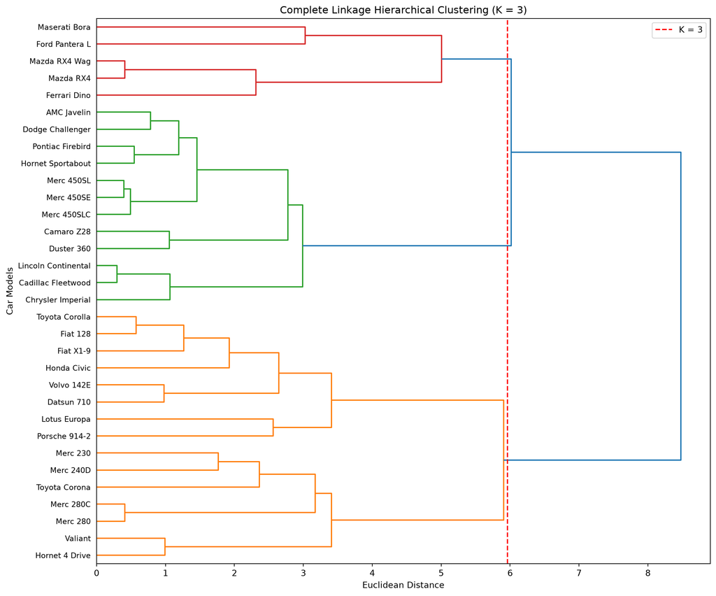

```python
from scipy.cluster.hierarchy import fcluster

# Choose linkage method and number of clusters
K = 3

# Cut the complete-linkage dendrogram into 3 clusters
cluster_labels = fcluster(
    hc_complete,
    t=K,
    criterion="maxclust"
)

# Add cluster labels to original data
mtcars_clustered = mtcars.copy()
mtcars_clustered["Cluster"] = cluster_labels

# Display cluster sizes
print("Cluster Sizes:")
print(mtcars_clustered["Cluster"].value_counts().sort_index())

# Report cluster memberships

print("\nCluster Memberships:")

for k in range(1, K + 1):

    members = mtcars_clustered.loc[
        mtcars_clustered["Cluster"] == k,
        "car"
    ].tolist()

    print(f"\nCluster {k} ({len(members)} cars):")

    for car in members:
        print(f"  {car}")

# Calculate cluster means using ORIGINAL variable scales

cluster_means = (
    mtcars_clustered
    .groupby("Cluster")[X.columns]
    .mean()
)

print("\nCluster Means (Original Variable Scales):")
print(cluster_means.round(2).to_string())

# Plot complete-linkage dendrogram with K = 3

plt.figure(figsize=(12, 10))

dendrogram(
    hc_complete,
    labels=car_names.to_numpy(),
    orientation="right",
    leaf_font_size=9
)

# Determine the cut height between the last two merges
# below the final K = 3 clusters
cut_height = (
    hc_complete[-K, 2] + hc_complete[-K + 1, 2]
) / 2

plt.axvline(
    x=cut_height,
    color="red",
    linestyle="--",
    label=f"K = {K}"
)

plt.title("Complete Linkage Hierarchical Clustering (K = 3)")
plt.xlabel("Euclidean Distance")
plt.ylabel("Car Models")
plt.legend()
plt.tight_layout()
plt.show()
```

We selected complete linkage with $K=3$ because the dendrogram shows three reasonably separated groups.

Cluster 1 (15 cars) consists of relatively fuel-efficient, lightweight cars, with the highest average mpg (24.65) and lowest horsepower (91.33).

Cluster 2 (12 cars) contains heavier, large-engine cars, with the lowest mpg (15.05) and highest weight (4.10).

Cluster 3 (5 cars) is more performance-oriented, with the highest horsepower (198.80) and shortest quarter-mile time (15.62).

These differences support the choice of three clusters. Standardization ensures that variables with larger numerical scales do not dominate the Euclidean distances.